# Uygulama: Basit Regresyon Analizi

Finansal Ekonometri (MPİ-TYL)

Prof. Dr. Hüseyin Taştan

Yıldız Teknik Üniversitesi

# 1 Örnek: CEO maaşları ve karlılık

```r
library(wooldridge)
data(ceosal1)
# View(ceosal1)
```

`ceosal1` veri setinde yer alan CEO maaşları `salary` değişkeninin karlılık `roe` üzerine basit regresyonunu kuralım:
$$salary = \beta_0 + \beta_1 roe +
u$$

Değişken tanımlar:  
**salary**: yıllık CEO maaşları (1000 US$), **roe**: Son üç yıldaki ortalama sermaye başına getiri oranı.

Regresyon modelini tahmin etmek için R’daki `lm()` fonksiyonunu kullanabiliriz:

```r
library(wooldridge)
lm(salary ~ roe, data = ceosal1)
```

```
##
## Call:
## lm(formula = salary ~ roe, data = ceosal1)
##
## Coefficients:
## (Intercept)          roe
##       963.2         18.5
```

Tahmin sonuçları denklem formunda aşağıdaki gibi yazılabilir:
$$\widehat{salary} = 963.191 + 18.501
roe$$

Alternatif olarak:
$$salary = 963.191 + 18.501 roe + \hat{u}$$

Burada $\hat{u}$ kalıntı (residual) terimidir. Burada
$$salary = \widehat{salary} + \widehat{u}$$
olduğuna dikkat ediniz.

**Eğim katsayısının yorumu:** Getiri oranındaki yüzde 1 puanlık bir artışa karşılık ( $\Delta roe = 1$ ) CEO yıllık maaşlarında ceteris paribus ortalama 18.501 birim (1000 USD) artış tahmin edilmiştir:
$$\Delta salary = 18.501 \Delta roe =
18.501,~~~\Delta roe=1$$

Derste gördüğümüz basit regresyon formüllerini kullanarak da katsayı tahminlerini bulabiliriz.

```r
attach(ceosal1)
# intermediate computations
cov(roe,salary)
```

```
## [1] 1342.538
```

```r
var(roe)
```

```
## [1] 72.56499
```

```r
mean(salary)
```

```
## [1] 1281.12
```

```r
mean(roe)
```

```
## [1] 17.18421
```

```r
# manual calculation of OLS coefficients
( b1hat <- cov(roe,salary)/var(roe) )
```

```
## [1] 18.50119
```

```r
( b0hat <- mean(salary) - b1hat*mean(roe) )
```

```
## [1] 963.1913
```

```r
detach(ceosal1)
```

`lm()` fonksiyonunun çıktısı bir listedir:

```r
results1 <- lm(salary ~ roe, data = ceosal1)
# View(results1)
summary(results1)
```

```
##
## Call:
## lm(formula = salary ~ roe, data = ceosal1)
##
## Residuals:
##     Min      1Q  Median      3Q     Max
## -1160.2  -526.0  -254.0   138.8 13499.9
##
## Coefficients:
##             Estimate Std. Error t value Pr(>|t|)
## (Intercept)   963.19     213.24   4.517 1.05e-05 ***
## roe            18.50      11.12   1.663   0.0978 .
## ---
## Signif. codes:  0 '***' 0.001 '**' 0.01 '*' 0.05 '.' 0.1 ' ' 1
##
## Residual standard error: 1367 on 207 degrees of freedom
## Multiple R-squared:  0.01319,    Adjusted R-squared:  0.008421
## F-statistic: 2.767 on 1 and 207 DF,  p-value: 0.09777
```

`results1` listesinde katsayı tahminleri, kalıntılar, y için kestirim değerleri, vs. bulunmaktadır.

Verilerin ve regresyon doğrusunun görselleştirilmesi:

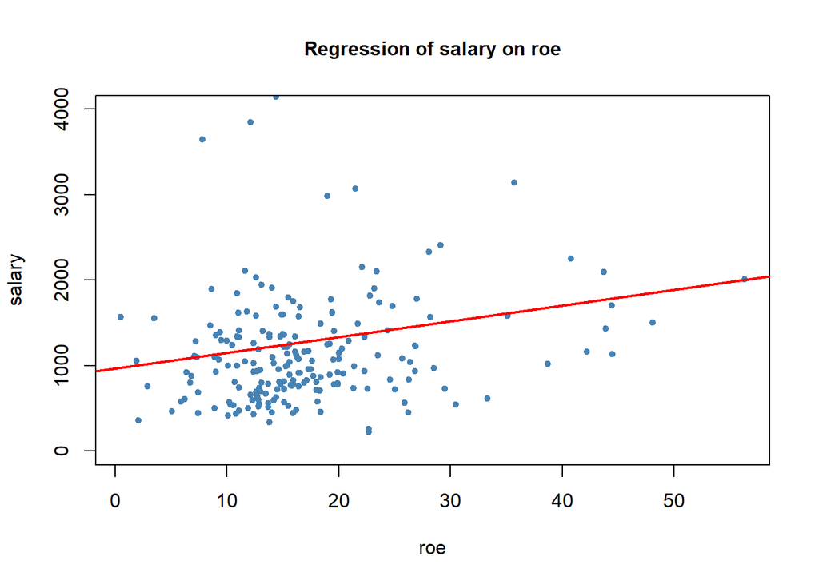

```r
attach(ceosal1)
plot(roe, salary,
     ylim = c(0,4000),
     col = "steelblue",
     pch = 20,
     main = "Regression of salary on roe",
     cex.main = 1)
abline(results1,
       col = "red",
       lwd = 2)
```

Gözlenen ve tahmin edilen y değerleri ve kalıntılar:

```r
salaryhat <- fitted(results1)
uhat <- resid(results1)
table2.2 <- cbind(roe, salary, salaryhat, uhat)
head(table2.2,n=15)
```

```
##     roe salary salaryhat        uhat
## 1  14.1   1095  1224.058 -129.058071
## 2  10.9   1001  1164.854 -163.854261
## 3  23.5   1122  1397.969 -275.969216
## 4   5.9    578  1072.348 -494.348338
## 5  13.8   1368  1218.508  149.492288
## 6  20.0   1145  1333.215 -188.215063
## 7  16.4   1078  1266.611 -188.610785
## 8  16.3   1094  1264.761 -170.760660
## 9  10.5   1237  1157.454   79.546207
## 10 26.3    833  1449.773 -616.772523
## 11 25.9    567  1442.372 -875.372056
## 12 26.8    933  1459.023 -526.023116
## 13 14.8   1339  1237.009  101.991102
## 14 22.3    937  1375.768 -438.767778
## 15 56.3   2011  2004.808    6.191886
```

# 2 OLS tahmincilerinin cebirsel özellikleri

1. Kalıntıların toplamı ve ortalaması her zaman sıfırdır:

```r
sum(results1$residuals)
```

```
## [1] -3.17435e-12
```

```r
mean(results1$residuals)
```

```
## [1] -1.525415e-14
```

2. $x$ ile kalıntılar arasındak örneklem kovaryansı sıfırdır:

```r
sum(results1$residuals*ceosal1$roe)
```

```
## [1] -7.140954e-12
```

```r
cov(results1$residuals, ceosal1$roe)
```

```
## [1] 2.474281e-13
```

3. $(\bar{x},\bar{y})$ noktası her zaman regresyon doğrusu üzerindedir:

```r
roemean <- mean(ceosal1$roe)
salarymean <- mean(ceosal1$salary)
salarymean
```

```
## [1] 1281.12
```

```r
salaryhatmean <- b0hat + b1hat*roemean
salaryhatmean
```

```
## [1] 1281.12
```

4. Kestirim değerlerinin ortalaması gözlenen değerlerin ortalamasına eşittir: $\bar{y}=\bar{\hat{y}}$

```r
mean(results1$fitted.values)
```

```
## [1] 1281.12
```

```r
mean(ceosal1$salary)
```

```
## [1] 1281.12
```

$R^2$’nin üç farklı yolla hesaplanması:

```r
data(ceosal1, package='wooldridge')

CEOregres <- lm( salary ~ roe, data=ceosal1 )

# Calculate predicted values & residuals:
sal.hat <- fitted(CEOregres)
u.hat <- resid(CEOregres)

# Calculate R^2 in three different ways:
sal <- ceosal1$salary
var(sal.hat) / var(sal)
```

```
## [1] 0.01318862
```

```r
1 - var(u.hat) / var(sal)
```

```
## [1] 0.01318862
```

```r
cor(sal, sal.hat)^2
```

```
## [1] 0.01318862
```

# 3 Örnek: GPA regresyonu

```r
gpareg <- lm(formula = colGPA ~ hsGPA, data = gpa1)
summary(gpareg)
```

```
##
## Call:
## lm(formula = colGPA ~ hsGPA, data = gpa1)
##
## Residuals:
##      Min       1Q   Median       3Q      Max
## -0.85220 -0.26274 -0.04868  0.28902  0.88551
##
## Coefficients:
##             Estimate Std. Error t value Pr(>|t|)
## (Intercept)  1.41543    0.30694   4.611 8.98e-06 ***
## hsGPA        0.48243    0.08983   5.371 3.21e-07 ***
## ---
## Signif. codes:  0 '***' 0.001 '**' 0.01 '*' 0.05 '.' 0.1 ' ' 1
##
## Residual standard error: 0.34 on 139 degrees of freedom
## Multiple R-squared:  0.1719, Adjusted R-squared:  0.1659
## F-statistic: 28.85 on 1 and 139 DF,  p-value: 3.211e-07
```

R-kare:

```r
# ratio of the variance of fitted values to the variance of x
colGPAhat <- fitted(gpareg)
var(colGPAhat)/var(gpa1$colGPA)
```

```
## [1] 0.1718563
```

```r
# or
cor(colGPAhat, gpa1$colGPA)^2
```

```
## [1] 0.1718563
```

**Alıştırma**: Örneklem regresyon fonksiyonunu denklem formunda yazınız ve eğim katsayısını yorumlayınız. Serpilme grafiği ile regresyon doğrusunu aynı grafikte çiziniz.

# 4 Örnek: Ücret denklemi

```r
data(wage1, package='wooldridge')

# OLS regression:
WAGEregres <- lm(wage ~ educ, data=wage1)

# obtain coefficients, predicted values and residuals
b.hat <- coef(WAGEregres)
wage.hat <- fitted(WAGEregres)
u.hat <- resid(WAGEregres)

# Algebraic property (1):
mean(u.hat)
```

```
## [1] -1.19498e-16
```

```r
# Algebraic property (2):
cor(wage1$educ , u.hat)
```

```
## [1] 4.349557e-16
```

```r
#Algebraic property (3):
mean(wage1$wage)
```

```
## [1] 5.896103
```

```r
b.hat[1] + b.hat[2] * mean(wage1$educ)
```

```
## (Intercept)
##    5.896103
```

Regresyon çıktısı:

```r
summary(WAGEregres)
```

```
##
## Call:
## lm(formula = wage ~ educ, data = wage1)
##
## Residuals:
##     Min      1Q  Median      3Q     Max
## -5.3396 -2.1501 -0.9674  1.1921 16.6085
##
## Coefficients:
##             Estimate Std. Error t value Pr(>|t|)
## (Intercept) -0.90485    0.68497  -1.321    0.187
## educ         0.54136    0.05325  10.167   <2e-16 ***
## ---
## Signif. codes:  0 '***' 0.001 '**' 0.01 '*' 0.05 '.' 0.1 ' ' 1
##
## Residual standard error: 3.378 on 524 degrees of freedom
## Multiple R-squared:  0.1648, Adjusted R-squared:  0.1632
## F-statistic: 103.4 on 1 and 524 DF,  p-value: < 2.2e-16
```

# 5 Verilerin görselleştirilmesinin önemi

```r
library(datasets)
anscombe
```

```
##    x1 x2 x3 x4    y1   y2    y3    y4
## 1  10 10 10  8  8.04 9.14  7.46  6.58
## 2   8  8  8  8  6.95 8.14  6.77  5.76
## 3  13 13 13  8  7.58 8.74 12.74  7.71
## 4   9  9  9  8  8.81 8.77  7.11  8.84
## 5  11 11 11  8  8.33 9.26  7.81  8.47
## 6  14 14 14  8  9.96 8.10  8.84  7.04
## 7   6  6  6  8  7.24 6.13  6.08  5.25
## 8   4  4  4 19  4.26 3.10  5.39 12.50
## 9  12 12 12  8 10.84 9.13  8.15  5.56
## 10  7  7  7  8  4.82 7.26  6.42  7.91
## 11  5  5  5  8  5.68 4.74  5.73  6.89
```

Bu veri setinde “Anscombe’s Quartet” isimli yapay verileri yer almaktadır. (bkz F.J. Anscombe, 1973, Graphs in Statistical Analysis, The American Statistician, vol.27, No.1, pp.17-21, [click here for pdf version](http://www.jstor.com/stable/2682899)).

Bu veri setinde dört $x,y$ çifti yer almaktadır. $y$ bağımlı değişkeni, $x$ açıklayıcı değişkeni ifade etmektedir.

Serpilme çizimlerini oluşturalım:

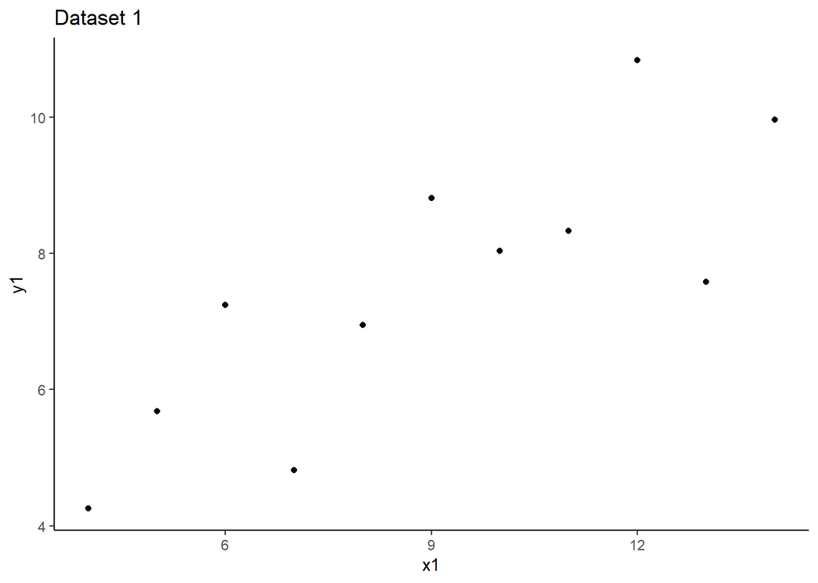

```r
library(ggplot2)
plot1 <- ggplot(anscombe) +
  geom_point(aes(x1, y1)) +
  labs(x="x1", y="y1", title="Dataset 1") +
  theme_classic()
plot1
```

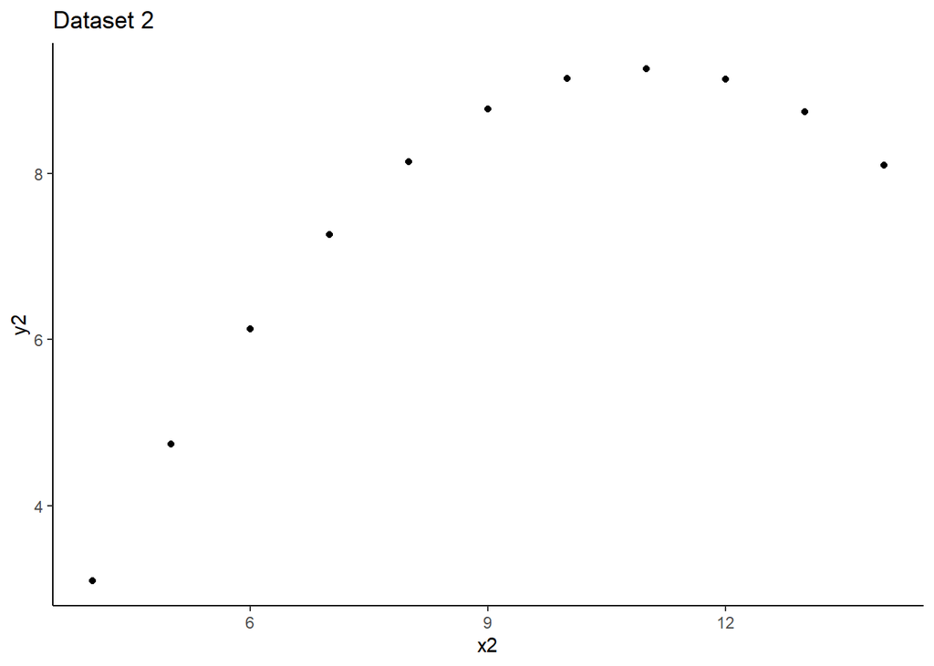

```r
plot2 <- ggplot(anscombe) +
  geom_point(aes(x2, y2)) +
  labs(x="x2", y="y2", title="Dataset 2") +
  theme_classic()
plot2
```

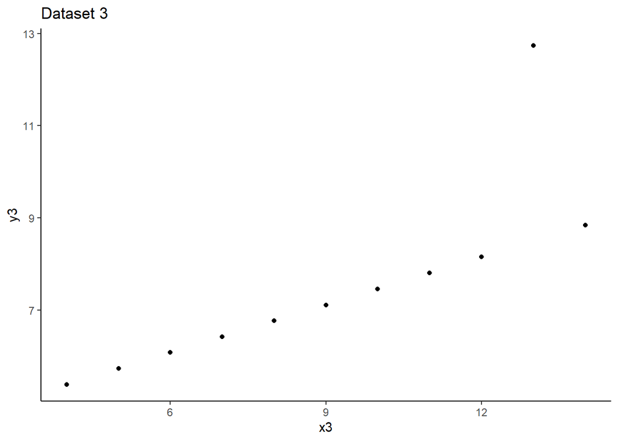

```r
plot3 <- ggplot(anscombe) +
  geom_point(aes(x3, y3)) +
  labs(x="x3", y="y3", title="Dataset 3") +
  theme_classic()
plot3
```

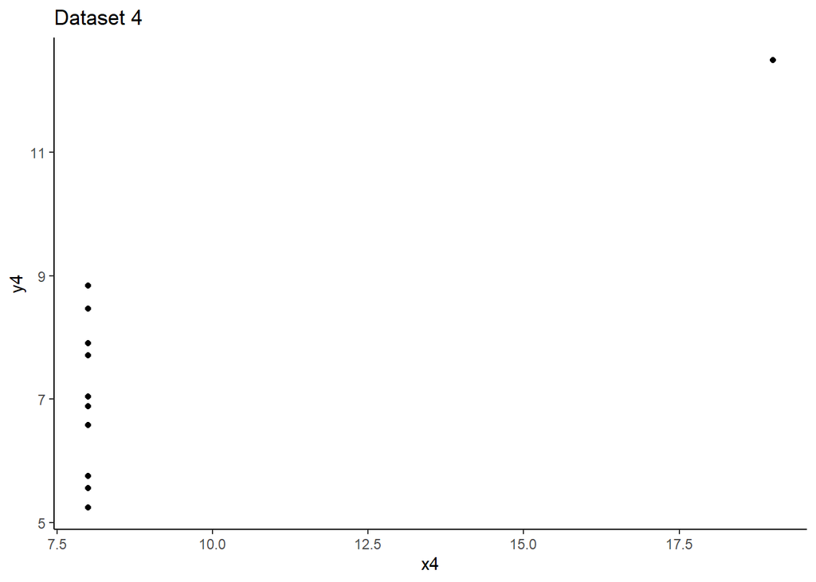

```r
plot4 <- ggplot(anscombe) +
  geom_point(aes(x4, y4)) +
  labs(x="x4", y="y4", title="Dataset 4") +
  theme_classic()
plot4
```

Bu grafikleri birleştirelim:

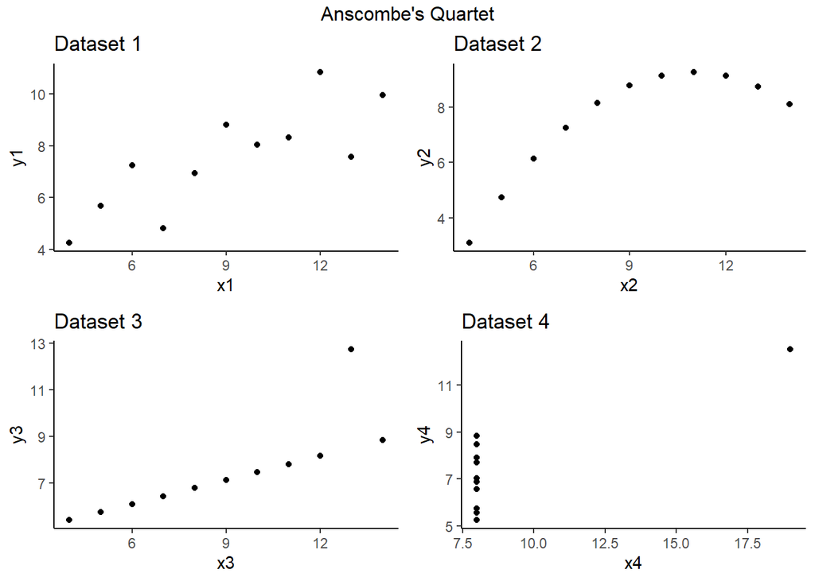

```r
library(grid)
library(gridExtra)
grid.arrange(grobs=list(plot1, plot2, plot3, plot4),
             ncol=2, top="Anscombe's Quartet")
```

OLS tahmin sonuçları:

```r
reg1 <- lm(y1 ~ x1, data = anscombe)
reg1
```

```
##
## Call:
## lm(formula = y1 ~ x1, data = anscombe)
##
## Coefficients:
## (Intercept)           x1
##      3.0001       0.5001
```

```r
reg2 <- lm(y2 ~ x2, data = anscombe)
reg2
```

```
##
## Call:
## lm(formula = y2 ~ x2, data = anscombe)
##
## Coefficients:
## (Intercept)           x2
##       3.001        0.500
```

```r
reg3 <- lm(y3 ~ x3, data = anscombe)
reg3
```

```
##
## Call:
## lm(formula = y3 ~ x3, data = anscombe)
##
## Coefficients:
## (Intercept)           x3
##      3.0025       0.4997
```

```r
reg4 <- lm(y4 ~ x4, data = anscombe)
reg4
```

```
##
## Call:
## lm(formula = y4 ~ x4, data = anscombe)
##
## Coefficients:
## (Intercept)           x4
##      3.0017       0.4999
```

Çözümlerin aynı olduğuna dikkat ediniz:
$$\widehat{y} = 3.00 + 0.5~x$$

Fit edilen regresyon doğruları ile veri grafiklerini birleştirelim:

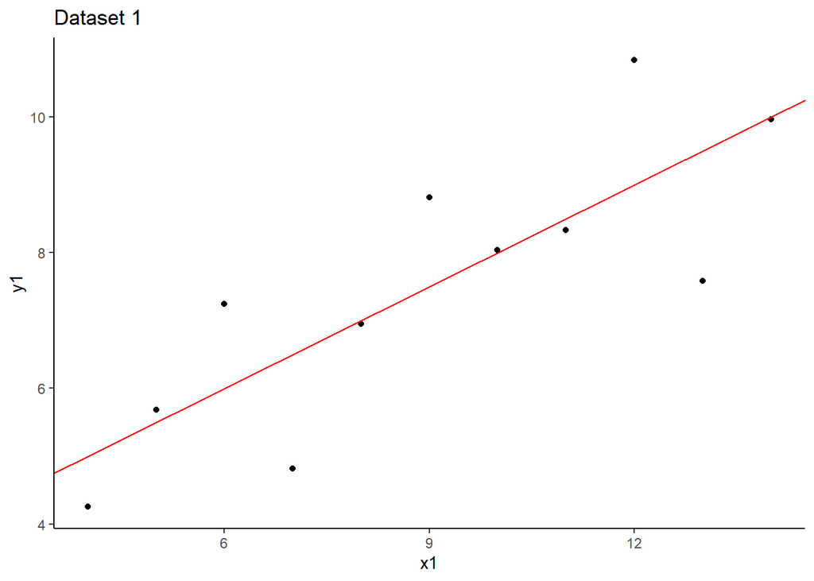

```r
fplot1 <- plot1 + geom_abline(intercept = reg1$coefficients[1],
                              slope = reg1$coefficients[2], color = "red")
fplot1
```

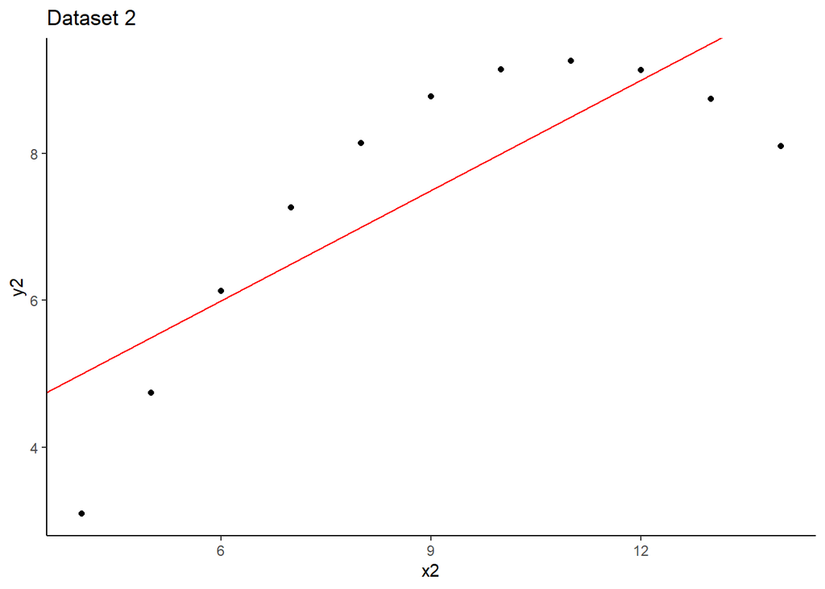

```r
fplot2 <- plot2 + geom_abline(intercept = reg2$coefficients[1],
                              slope = reg2$coefficients[2], color = "red")
fplot2
```

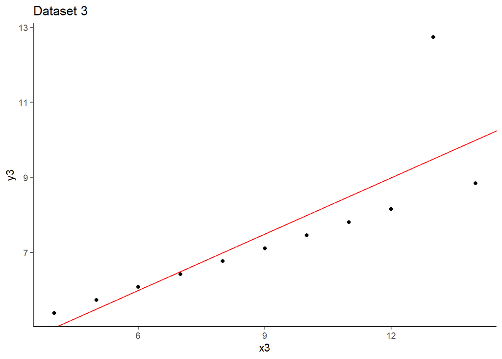

```r
fplot3 <- plot3 + geom_abline(intercept = reg3$coefficients[1],
                              slope = reg3$coefficients[2], color = "red")
fplot3
```

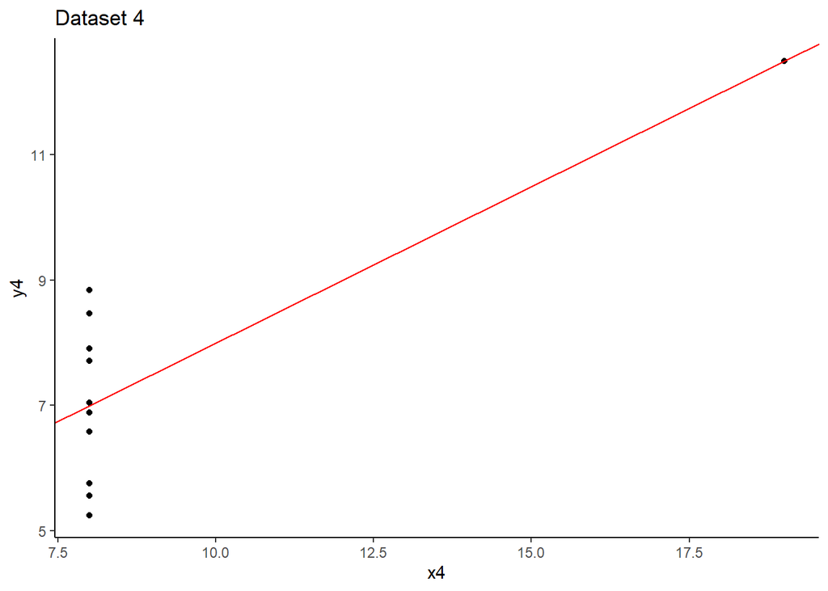

```r
fplot4 <- plot4 + geom_abline(intercept = reg4$coefficients[1],
                              slope = reg4$coefficients[2], color = "red")
fplot4
```

Hepsi birlikte:

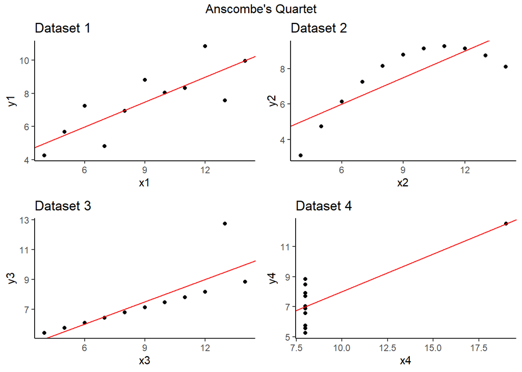

```r
library(grid)
library(gridExtra)
grid.arrange(grobs=list(fplot1, fplot2, fplot3, fplot4),
             ncol=2, top="Anscombe's Quartet")
```

Bazı yorumları:

Dataset1: Regresyon doğrusu veri noktalarına iyi bir uyum sağlamaktadır. OLS regresyonunun uygun olduğu söylenebilir.

Dataset2: Serpilme çizimine göre değişkenler arasında doğrusal olmayan (karesel) bir ilişki mevcuttur. OLS regresyonu uygun değildir.

Dataset3: Serpilme çizimine göre bir ekstrem değer mevcuttur. Bu nokta dışlanırsa aşağı yukarı doğrusal bir ilişki vardır.

Dataset4: Bu veri kümesinde tüm $x$ değerleri, biri dışında, aynı değere sahiptir. Eğer bu ayrık değer dışlanırsa verilerde değişkenlik kalmaz (varyans sıfır olur). Bu durumda model çözülemez.

**Alıştırma:** Anscombe’s quartet verileri için kalıntıları hesaplayınız ve $x$ değişkenine göre serpilme çizimlerini oluşturunuz.

# 6 Örnek: Ücret-eğitim modeli (log-level)

```r
library(wooldridge)
data(wage1)
```

Logaritmik ücretlerin (wage) eğitim düzeyi (educ) üzerine regresyonu:

$$log(wage) = \beta_0 + \beta_1 educ +
u$$

```r
wagereg <- lm(log(wage) ~ educ, data = wage1)
# View(wagereg)
summary(wagereg)
```

```
##
## Call:
## lm(formula = log(wage) ~ educ, data = wage1)
##
## Residuals:
##      Min       1Q   Median       3Q      Max
## -2.21158 -0.36393 -0.07263  0.29712  1.52339
##
## Coefficients:
##             Estimate Std. Error t value Pr(>|t|)
## (Intercept) 0.583773   0.097336   5.998 3.74e-09 ***
## educ        0.082744   0.007567  10.935  < 2e-16 ***
## ---
## Signif. codes:  0 '***' 0.001 '**' 0.01 '*' 0.05 '.' 0.1 ' ' 1
##
## Residual standard error: 0.4801 on 524 degrees of freedom
## Multiple R-squared:  0.1858, Adjusted R-squared:  0.1843
## F-statistic: 119.6 on 1 and 524 DF,  p-value: < 2.2e-16
```

Denklem formunda yazalım:
$$\widehat{log(wage)} = 0.584 + 0.083
educ$$

**Eğim katsayısının yorumu**: Eğitim düzeyi bir yıl artarsa ortalama saat başına ücretlerin yaklaşık yüzde 8.3 artacağı tahmin edilmiştir. Yani,
$$\Delta\widehat{\log(wage)} = 0.083\Delta
educ$$
Her iki tarafı 100 ile çarparak yüzde ile ifade edebiliriz:
$$\%\Delta wage\approx \%
8.3,~~~\Delta educ = 1$$

Eğitim düzeyi 4 yıl artarsa tahmin edilen ücret artışı ortalama $\% (4\times8.3) = \% 33.2$ olur.

Grafiksel gösterim:

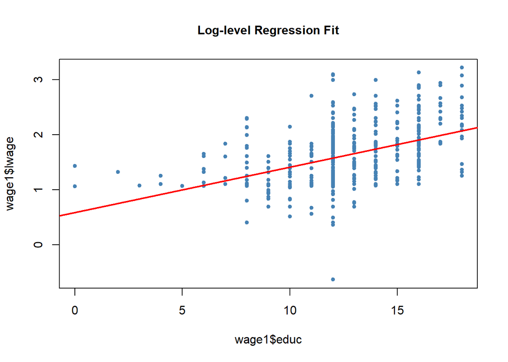

```r
plot(wage1$educ, wage1$lwage,
     col = "steelblue",
     pch = 20,
     main = "Log-level Regression Fit",
     cex.main = 1)
abline(wagereg,
       col = "red",
       lwd = 2)
```

Level-level regresyonu ile karşılaştıralım:

```r
wagereg2 <- lm(wage ~ educ, data = wage1)
# View(wagereg2)
summary(wagereg2)
```

```
##
## Call:
## lm(formula = wage ~ educ, data = wage1)
##
## Residuals:
##     Min      1Q  Median      3Q     Max
## -5.3396 -2.1501 -0.9674  1.1921 16.6085
##
## Coefficients:
##             Estimate Std. Error t value Pr(>|t|)
## (Intercept) -0.90485    0.68497  -1.321    0.187
## educ         0.54136    0.05325  10.167   <2e-16 ***
## ---
## Signif. codes:  0 '***' 0.001 '**' 0.01 '*' 0.05 '.' 0.1 ' ' 1
##
## Residual standard error: 3.378 on 524 degrees of freedom
## Multiple R-squared:  0.1648, Adjusted R-squared:  0.1632
## F-statistic: 103.4 on 1 and 524 DF,  p-value: < 2.2e-16
```

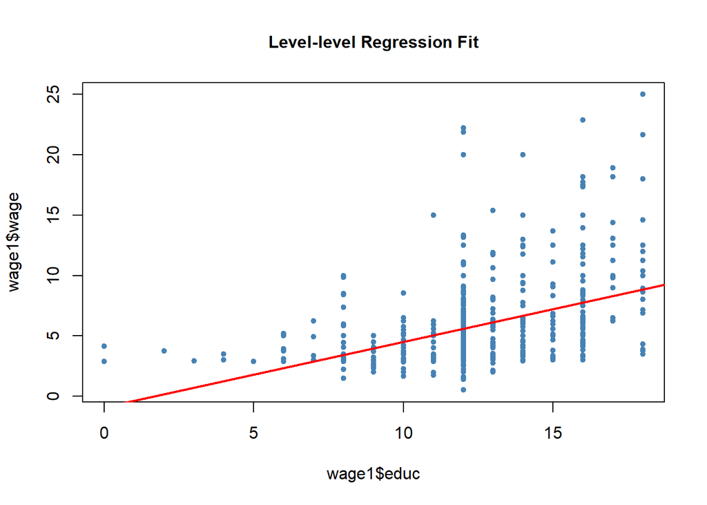

```r
plot(wage1$educ, wage1$wage,
     col = "steelblue",
     pch = 20,
     main = "Level-level Regression Fit",
     cex.main = 1)
abline(wagereg2,
       col = "red",
       lwd = 2)
```

# 7 Örnek: Test sonuçları ve bölgesel gelir (Level-log )

## 7.1 Level-level

Level-level modeli (orijinal ölçümlerle):

$$Test~ Score = \beta_0 + \beta_1 Income +
u$$

Değişken tanımları:  
Test score: o bölgedeki ortalama test puanı; Income: o bölgedeki gelir düzeyi (1000 US$).

```r
# Install the AER package if you haven't done so.
# install.packages("AER")
library(AER)
data(CASchools)
# prepare variables
CASchools$size <- CASchools$students/CASchools$teachers
CASchools$score <- (CASchools$read + CASchools$math) / 2

# fit a level-level model
linear_model<- lm(score ~ income, data = CASchools)
summary(linear_model)
```

```
##
## Call:
## lm(formula = score ~ income, data = CASchools)
##
## Residuals:
##     Min      1Q  Median      3Q     Max
## -39.574  -8.803   0.603   9.032  32.530
##
## Coefficients:
##             Estimate Std. Error t value Pr(>|t|)
## (Intercept) 625.3836     1.5324  408.11   <2e-16 ***
## income        1.8785     0.0905   20.76   <2e-16 ***
## ---
## Signif. codes:  0 '***' 0.001 '**' 0.01 '*' 0.05 '.' 0.1 ' ' 1
##
## Residual standard error: 13.39 on 418 degrees of freedom
## Multiple R-squared:  0.5076, Adjusted R-squared:  0.5064
## F-statistic: 430.8 on 1 and 418 DF,  p-value: < 2.2e-16
```

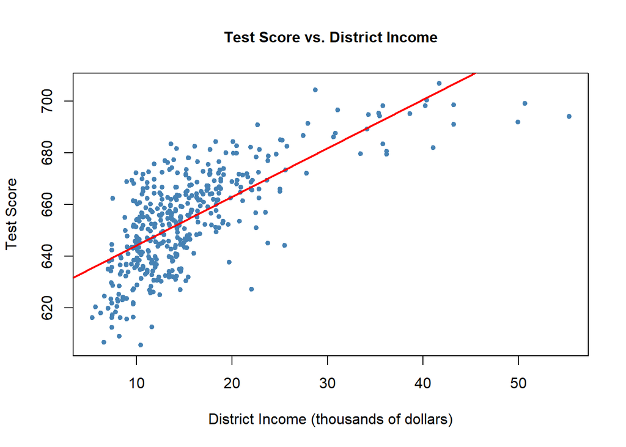

```r
# plot the observations
plot(CASchools$income, CASchools$score,
     col = "steelblue",
     pch = 20,
     xlab = "District Income (thousands of dollars)",
     ylab = "Test Score",
     cex.main = 0.9,
     main = "Test Score vs. District Income",
     cex.main = 1)

# add the regression line to the plot
abline(linear_model,
       col = "red",
       lwd = 2)
```

**Alıştırma**: Örneklem regresyon fonksiyonunu denklem formunda yazınız ve sonuçları yorumlayınız.

## 7.2 level-log modeli

Model:

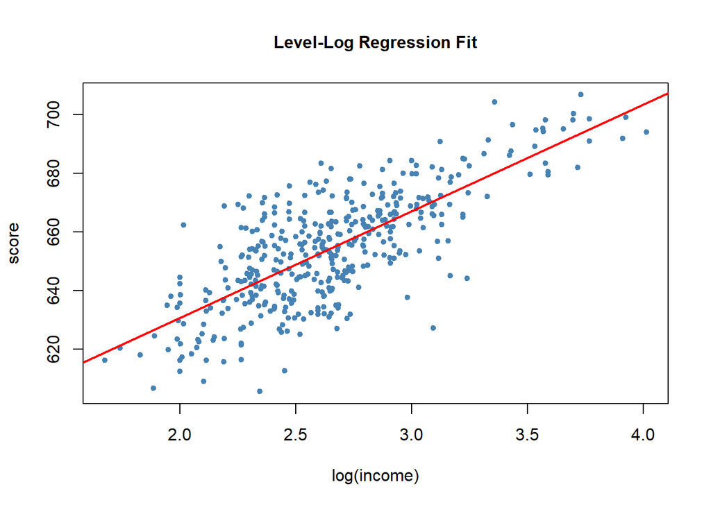

```r
LevelLog_model <- lm(score ~ log(income), data = CASchools)

# draw a scatterplot
plot(score ~ log(income),
     col = "steelblue",
     pch = 20,
     data = CASchools,
     main = "Level-Log Regression Fit",
     cex.main = 1)
abline(LevelLog_model,
       col = "red",
       lwd = 2)
```

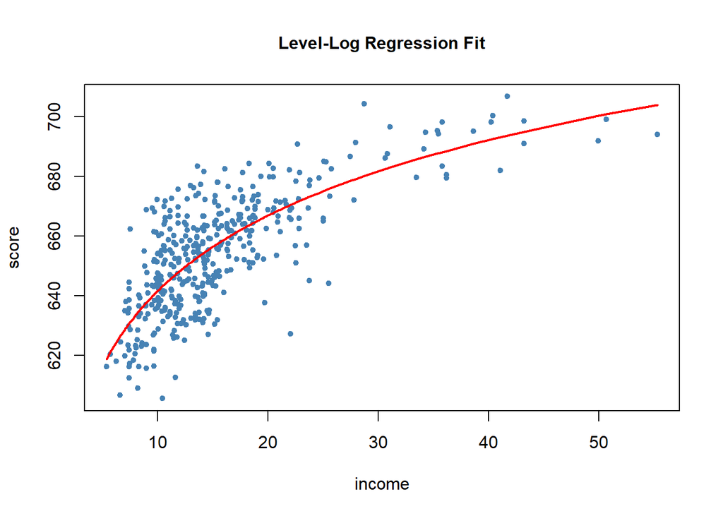

```r
# Income in original levels (1000 US$)
# and add regression fitted values
plot(score ~ income,
     col = "steelblue",
     pch = 20,
     data = CASchools,
     main = "Level-Log Regression Fit",
     cex.main = 1)

# add the linear-log regression line
order_id  <- order(CASchools$income)

lines(CASchools$income[order_id],
      fitted(LevelLog_model)[order_id],
      col = "red",
      lwd = 2)
```

Denklem formunda yazarsak:

$$\widehat{score} = 557.832 +
36.42\log(income)$$
**Eğim katsayısının yorumu**: Gelir düzeyindeki %1 artışa karşılık test sonuçlarında ortalamada yaklaşık 0.36 (=36.42/100) puanlık bir artış tahmin edilmiştir. Gelirde %10 bir artış olursa test sonuçlarında tahmin edilen ortalama artış yaklaşık 3.64 puan olacaktır.

# 8 Örnek: CEO maaşları ve satışlar (Log-log ):

Model:
$$log(salary) = \beta_0 + \beta_1
log(sales) + u$$

R çözümü:

```r
LogLog_model <- lm(log(salary) ~ log(sales), data = ceosal1)
# View(LogLog_model)
summary(LogLog_model)
```

```
##
## Call:
## lm(formula = log(salary) ~ log(sales), data = ceosal1)
##
## Residuals:
##      Min       1Q   Median       3Q      Max
## -1.01038 -0.28140 -0.02723  0.21222  2.81128
##
## Coefficients:
##             Estimate Std. Error t value Pr(>|t|)
## (Intercept)  4.82200    0.28834  16.723  < 2e-16 ***
## log(sales)   0.25667    0.03452   7.436  2.7e-12 ***
## ---
## Signif. codes:  0 '***' 0.001 '**' 0.01 '*' 0.05 '.' 0.1 ' ' 1
##
## Residual standard error: 0.5044 on 207 degrees of freedom
## Multiple R-squared:  0.2108, Adjusted R-squared:  0.207
## F-statistic:  55.3 on 1 and 207 DF,  p-value: 2.703e-12
```

**Eğim katsayısının yorumu**: CEO maaşlarının firma satışlarına göre esnekliği 0.257 olarak tahmin edilmiştir. Yani satışlarda %1 artışa karşılık CEO maaşlarında modelce kestirilen ortalama artış yaklaşık % 0.257’dir (inelastik).

Denklem formunda:
$$\widehat{\log(salary)} = 4.822 + 0.257~~ \log(sales)$$

Görselleştirme:

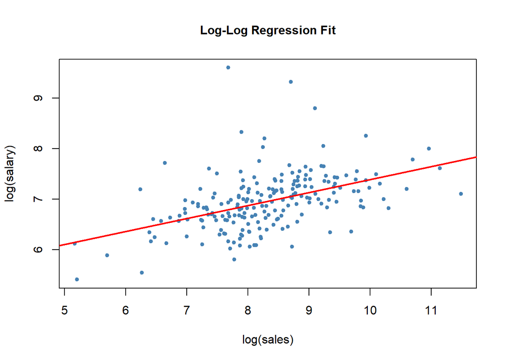

```r
plot(log(salary) ~ log(sales),
     col = "steelblue",
     pch = 20,
     data = ceosal1,
     main = "Log-Log Regression Fit",
     cex.main = 1)
abline(LogLog_model,
       col = "red",
       lwd = 2)
```

**Alıştırma**: Level-level regresyonunu tahmin ediniz ve sonuçları görselleştiriniz. Log-log sonuçları ile karşılaştırınız. Hangisi daha iyi bir uyum sağlıyor?